# R Notebook

The path of the decision tree same as the above trees.The overall accuracy of the model is 69%, which means it correctly predicts the star rating of a hotel based on these features about 69% of the time. This metric gives an indication of the model’s performance on the dataset it was tested on

```r
set.seed(1234)
ind <- sample(2, nrow(yes), replace=TRUE, prob=c(0.8, 0.2))
trainData <- yes[ind==1,]
testData <- yes[ind==2,]

#install.packages('party')
library(party)

myFormula <- Hotel.stars ~ Pool + Gym + Spa + Free.internet + Tennis.court + Casino
dataset_ctree <- ctree(myFormula, data=trainData)

table(predict(dataset_ctree), trainData$Hotel.stars)
```

```
##
##         3 3.5   4 4.5   5
##   3    40   0   0   0   0
##   3.5   0  39   0   0   0
##   4    18   0  60   0  17
##   4.5   0   0   0  20   0
##   5    19  19  43   0 134
```

```r
print(dataset_ctree)
```

```
##
##   Conditional inference tree with 8 terminal nodes
##
## Response:  Hotel.stars
## Inputs:  Pool, Gym, Spa, Free.internet, Tennis.court, Casino
## Number of observations:  409
##
## 1) Gym == {1}; criterion = 1, statistic = 408
##   2) Spa == {1}; criterion = 1, statistic = 190.805
##     3) Free.internet == {1}; criterion = 1, statistic = 45.125
##       4) Tennis.court == {0}; criterion = 1, statistic = 53.734
##         5)*  weights = 215
##       4) Tennis.court == {1}
##         6)*  weights = 74
##     3) Free.internet == {0}
##       7)*  weights = 21
##   2) Spa == {0}
##     8) Tennis.court == {1}; criterion = 1, statistic = 28.966
##       9)*  weights = 21
##     8) Tennis.court == {0}
##       10) Pool == {0}; criterion = 0.999, statistic = 14.558
##         11)*  weights = 21
##       10) Pool == {1}
##         12) Casino == {1}; criterion = 1, statistic = 36
##           13)*  weights = 18
##         12) Casino == {0}
##           14)*  weights = 19
## 1) Gym == {0}
##   15)*  weights = 20
```

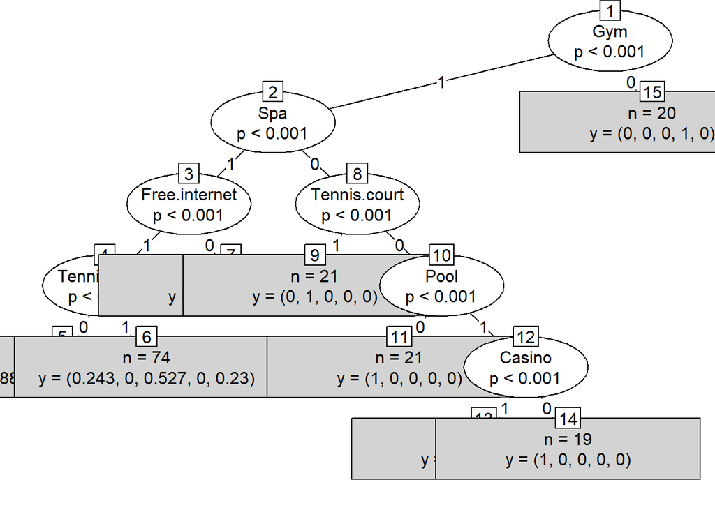

```r
plot(dataset_ctree,type="simple")
```

[figure not shown]

```r
plot(dataset_ctree)
```

```r
testPred <- predict(dataset_ctree, newdata = testData)
table(testPred, testData$Hotel.stars)
```

```
##
## testPred  3 3.5  4 4.5  5
##      3    8   0  0   0  0
##      3.5  0   9  0   0  0
##      4    6   0 10   0  7
##      4.5  0   0  0   4  0
##      5    5   5  5   0 34
```

```r
#install.packages('caret')
library(caret)
results <- confusionMatrix(testPred, testData$Hotel.stars)
acc <- results$overall["Accuracy"]*100
acc
```

```
## Accuracy
## 69.89247
```

```r
results
```

```
## Confusion Matrix and Statistics
##
##           Reference
## Prediction  3 3.5  4 4.5  5
##        3    8   0  0   0  0
##        3.5  0   9  0   0  0
##        4    6   0 10   0  7
##        4.5  0   0  0   4  0
##        5    5   5  5   0 34
##
## Overall Statistics
##
##                Accuracy : 0.6989
##                  95% CI : (0.595, 0.7897)
##     No Information Rate : 0.4409
##     P-Value [Acc > NIR] : 4.413e-07
##
##                   Kappa : 0.5661
##
##  Mcnemar's Test P-Value : NA
##
## Statistics by Class:
##
##                      Class: 3 Class: 3.5 Class: 4 Class: 4.5 Class: 5
## Sensitivity           0.42105    0.64286   0.6667    1.00000   0.8293
## Specificity           1.00000    1.00000   0.8333    1.00000   0.7115
## Pos Pred Value        1.00000    1.00000   0.4348    1.00000   0.6939
## Neg Pred Value        0.87059    0.94048   0.9286    1.00000   0.8409
## Prevalence            0.20430    0.15054   0.1613    0.04301   0.4409
## Detection Rate        0.08602    0.09677   0.1075    0.04301   0.3656
## Detection Prevalence  0.08602    0.09677   0.2473    0.04301   0.5269
## Balanced Accuracy     0.71053    0.82143   0.7500    1.00000   0.7704
```

```r
as.table(results)
```

```
##           Reference
## Prediction  3 3.5  4 4.5  5
##        3    8   0  0   0  0
##        3.5  0   9  0   0  0
##        4    6   0 10   0  7
##        4.5  0   0  0   4  0
##        5    5   5  5   0 34
```

```r
as.matrix(results)
```

```
##     3 3.5  4 4.5  5
## 3   8   0  0   0  0
## 3.5 0   9  0   0  0
## 4   6   0 10   0  7
## 4.5 0   0  0   4  0
## 5   5   5  5   0 34
```

```r
as.matrix(results, what = "overall")
```

```
##                        [,1]
## Accuracy       6.989247e-01
## Kappa          5.660723e-01
## AccuracyLower  5.950233e-01
## AccuracyUpper  7.897406e-01
## AccuracyNull   4.408602e-01
## AccuracyPValue 4.412807e-07
## McnemarPValue           NaN
```

```r
as.matrix(results, what = "classes")
```

```
##                               3        3.5         4        4.5         5
## Sensitivity          0.42105263 0.64285714 0.6666667 1.00000000 0.8292683
## Specificity          1.00000000 1.00000000 0.8333333 1.00000000 0.7115385
## Pos Pred Value       1.00000000 1.00000000 0.4347826 1.00000000 0.6938776
## Neg Pred Value       0.87058824 0.94047619 0.9285714 1.00000000 0.8409091
## Precision            1.00000000 1.00000000 0.4347826 1.00000000 0.6938776
## Recall               0.42105263 0.64285714 0.6666667 1.00000000 0.8292683
## F1                   0.59259259 0.78260870 0.5263158 1.00000000 0.7555556
## Prevalence           0.20430108 0.15053763 0.1612903 0.04301075 0.4408602
## Detection Rate       0.08602151 0.09677419 0.1075269 0.04301075 0.3655914
## Detection Prevalence 0.08602151 0.09677419 0.2473118 0.04301075 0.5268817
## Balanced Accuracy    0.71052632 0.82142857 0.7500000 1.00000000 0.7704034
```

```r
print(results)
```

```
## Confusion Matrix and Statistics
##
##           Reference
## Prediction  3 3.5  4 4.5  5
##        3    8   0  0   0  0
##        3.5  0   9  0   0  0
##        4    6   0 10   0  7
##        4.5  0   0  0   4  0
##        5    5   5  5   0 34
##
## Overall Statistics
##
##                Accuracy : 0.6989
##                  95% CI : (0.595, 0.7897)
##     No Information Rate : 0.4409
##     P-Value [Acc > NIR] : 4.413e-07
##
##                   Kappa : 0.5661
##
##  Mcnemar's Test P-Value : NA
##
## Statistics by Class:
##
##                      Class: 3 Class: 3.5 Class: 4 Class: 4.5 Class: 5
## Sensitivity           0.42105    0.64286   0.6667    1.00000   0.8293
## Specificity           1.00000    1.00000   0.8333    1.00000   0.7115
## Pos Pred Value        1.00000    1.00000   0.4348    1.00000   0.6939
## Neg Pred Value        0.87059    0.94048   0.9286    1.00000   0.8409
## Prevalence            0.20430    0.15054   0.1613    0.04301   0.4409
## Detection Rate        0.08602    0.09677   0.1075    0.04301   0.3656
## Detection Prevalence  0.08602    0.09677   0.2473    0.04301   0.5269
## Balanced Accuracy     0.71053    0.82143   0.7500    1.00000   0.7704
```

**classification-information gain - 3 (Training 90%, Test 10%)**

```r
set.seed(1234)
ind <- sample(2, nrow(yes), replace=TRUE, prob=c(0.9, 0.1))
trainData <- yes[ind==1,]
testData <- yes[ind==2,]

#install.packages('party')
library(party)

myFormula <- Hotel.stars ~ Pool + Gym + Spa + Free.internet + Tennis.court + Casino
dataset_ctree <- ctree(myFormula, data=trainData)

table(predict(dataset_ctree), trainData$Hotel.stars)
```

```
##
##         3 3.5   4 4.5   5
##   3    45   0   0   0   0
##   3.5   0  42   0   0   0
##   4    18   0  65   0  21
##   4.5   0   0   0  21   0
##   5    22  20  45   0 147
```

```r
print(dataset_ctree)
```

```
##
##   Conditional inference tree with 8 terminal nodes
##
## Response:  Hotel.stars
## Inputs:  Pool, Gym, Spa, Free.internet, Tennis.court, Casino
## Number of observations:  446
##
## 1) Gym == {1}; criterion = 1, statistic = 445
##   2) Spa == {1}; criterion = 1, statistic = 211.206
##     3) Free.internet == {0}; criterion = 1, statistic = 53.389
##       4)*  weights = 24
##     3) Free.internet == {1}
##       5) Tennis.court == {1}; criterion = 1, statistic = 51.92
##         6)*  weights = 80
##       5) Tennis.court == {0}
##         7)*  weights = 234
##   2) Spa == {0}
##     8) Tennis.court == {0}; criterion = 1, statistic = 29.318
##       9) Pool == {0}; criterion = 1, statistic = 16.225
##         10)*  weights = 23
##       9) Pool == {1}
##         11) Casino == {0}; criterion = 1, statistic = 42
##           12)*  weights = 22
##         11) Casino == {1}
##           13)*  weights = 21
##     8) Tennis.court == {1}
##       14)*  weights = 21
## 1) Gym == {0}
##   15)*  weights = 21
```

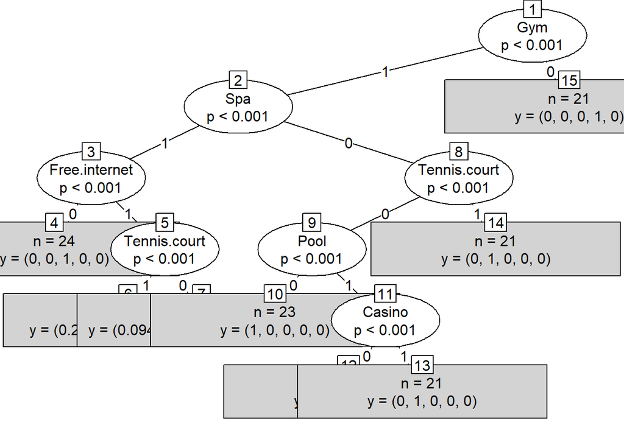

```r
plot(dataset_ctree,type="simple")
```

[figure not shown]

```r
plot(dataset_ctree)
```

```r
# predict on test data
testPred <- predict(dataset_ctree, newdata = testData)
table(testPred, testData$Hotel.stars)
```

```
##
## testPred  3 3.5  4 4.5  5
##      3    3   0  0   0  0
##      3.5  0   6  0   0  0
##      4    6   0  5   0  3
##      4.5  0   0  0   3  0
##      5    2   4  3   0 21
```

```r
#install.packages('caret')
library(caret)
results <- confusionMatrix(testPred, testData$Hotel.stars)
acc <- results$overall["Accuracy"]*100
acc
```

```
## Accuracy
## 67.85714
```

```r
results
```

```
## Confusion Matrix and Statistics
##
##           Reference
## Prediction  3 3.5  4 4.5  5
##        3    3   0  0   0  0
##        3.5  0   6  0   0  0
##        4    6   0  5   0  3
##        4.5  0   0  0   3  0
##        5    2   4  3   0 21
##
## Overall Statistics
##
##                Accuracy : 0.6786
##                  95% CI : (0.5404, 0.7971)
##     No Information Rate : 0.4286
##     P-Value [Acc > NIR] : 0.0001397
##
##                   Kappa : 0.5422
##
##  Mcnemar's Test P-Value : NA
##
## Statistics by Class:
##
##                      Class: 3 Class: 3.5 Class: 4 Class: 4.5 Class: 5
## Sensitivity           0.27273     0.6000  0.62500    1.00000   0.8750
## Specificity           1.00000     1.0000  0.81250    1.00000   0.7188
## Pos Pred Value        1.00000     1.0000  0.35714    1.00000   0.7000
## Neg Pred Value        0.84906     0.9200  0.92857    1.00000   0.8846
## Prevalence            0.19643     0.1786  0.14286    0.05357   0.4286
## Detection Rate        0.05357     0.1071  0.08929    0.05357   0.3750
## Detection Prevalence  0.05357     0.1071  0.25000    0.05357   0.5357
## Balanced Accuracy     0.63636     0.8000  0.71875    1.00000   0.7969
```

```r
as.table(results)
```

```
##           Reference
## Prediction  3 3.5  4 4.5  5
##        3    3   0  0   0  0
##        3.5  0   6  0   0  0
##        4    6   0  5   0  3
##        4.5  0   0  0   3  0
##        5    2   4  3   0 21
```

```r
as.matrix(results)
```

```
##     3 3.5 4 4.5  5
## 3   3   0 0   0  0
## 3.5 0   6 0   0  0
## 4   6   0 5   0  3
## 4.5 0   0 0   3  0
## 5   2   4 3   0 21
```

```r
as.matrix(results, what = "overall")
```

```
##                        [,1]
## Accuracy       0.6785714286
## Kappa          0.5422343324
## AccuracyLower  0.5403637655
## AccuracyUpper  0.7971454880
## AccuracyNull   0.4285714286
## AccuracyPValue 0.0001397439
## McnemarPValue           NaN
```

```r
as.matrix(results, what = "classes")
```

```
##                               3       3.5          4        4.5         5
## Sensitivity          0.27272727 0.6000000 0.62500000 1.00000000 0.8750000
## Specificity          1.00000000 1.0000000 0.81250000 1.00000000 0.7187500
## Pos Pred Value       1.00000000 1.0000000 0.35714286 1.00000000 0.7000000
## Neg Pred Value       0.84905660 0.9200000 0.92857143 1.00000000 0.8846154
## Precision            1.00000000 1.0000000 0.35714286 1.00000000 0.7000000
## Recall               0.27272727 0.6000000 0.62500000 1.00000000 0.8750000
## F1                   0.42857143 0.7500000 0.45454545 1.00000000 0.7777778
## Prevalence           0.19642857 0.1785714 0.14285714 0.05357143 0.4285714
## Detection Rate       0.05357143 0.1071429 0.08928571 0.05357143 0.3750000
## Detection Prevalence 0.05357143 0.1071429 0.25000000 0.05357143 0.5357143
## Balanced Accuracy    0.63636364 0.8000000 0.71875000 1.00000000 0.7968750
```

```r
print(results)
```

```
## Confusion Matrix and Statistics
##
##           Reference
## Prediction  3 3.5  4 4.5  5
##        3    3   0  0   0  0
##        3.5  0   6  0   0  0
##        4    6   0  5   0  3
##        4.5  0   0  0   3  0
##        5    2   4  3   0 21
##
## Overall Statistics
##
##                Accuracy : 0.6786
##                  95% CI : (0.5404, 0.7971)
##     No Information Rate : 0.4286
##     P-Value [Acc > NIR] : 0.0001397
##
##                   Kappa : 0.5422
##
##  Mcnemar's Test P-Value : NA
##
## Statistics by Class:
##
##                      Class: 3 Class: 3.5 Class: 4 Class: 4.5 Class: 5
## Sensitivity           0.27273     0.6000  0.62500    1.00000   0.8750
## Specificity           1.00000     1.0000  0.81250    1.00000   0.7188
## Pos Pred Value        1.00000     1.0000  0.35714    1.00000   0.7000
## Neg Pred Value        0.84906     0.9200  0.92857    1.00000   0.8846
## Prevalence            0.19643     0.1786  0.14286    0.05357   0.4286
## Detection Rate        0.05357     0.1071  0.08929    0.05357   0.3750
## Detection Prevalence  0.05357     0.1071  0.25000    0.05357   0.5357
## Balanced Accuracy     0.63636     0.8000  0.71875    1.00000   0.7969
```

**classification- gain ratio - 1 (3 folds)**

```r
set.seed(1958)
folds <- createFolds(yes$Hotel.stars, k = 3)

# Specify 'method' as "J48" and 'trControl' for classification
C45Fit <- train(Hotel.stars ~ Pool + Gym + Spa + Free.internet + Tennis.court + Casino ,method = "J48", data = yes, tuneLength = 5, trControl = trainControl(method = "cv", index = folds))
C45Fit
```

```
## C4.5-like Trees
##
## 502 samples
##   6 predictor
##   5 classes: '3', '3.5', '4', '4.5', '5'
##
## No pre-processing
## Resampling: Cross-Validated (10 fold)
## Summary of sample sizes: 167, 167, 168
## Resampling results across tuning parameters:
##
##   C       M  Accuracy   Kappa
##   0.0100  1  0.6941877  0.5621606
##   0.0100  2  0.6941877  0.5621606
##   0.0100  3  0.6941877  0.5621606
##   0.0100  4  0.6941877  0.5621606
##   0.0100  5  0.6941877  0.5621606
##   0.1325  1  0.7131498  0.5956007
##   0.1325  2  0.7131498  0.5956007
##   0.1325  3  0.7131498  0.5956007
##   0.1325  4  0.7131498  0.5956007
##   0.1325  5  0.7131498  0.5956007
##   0.2550  1  0.7131498  0.5956007
##   0.2550  2  0.7131498  0.5956007
##   0.2550  3  0.7131498  0.5956007
##   0.2550  4  0.7131498  0.5956007
##   0.2550  5  0.7131498  0.5956007
##   0.3775  1  0.7131498  0.5956007
##   0.3775  2  0.7131498  0.5956007
##   0.3775  3  0.7131498  0.5956007
##   0.3775  4  0.7131498  0.5956007
##   0.3775  5  0.7131498  0.5956007
##   0.5000  1  0.7131498  0.5956007
##   0.5000  2  0.7131498  0.5956007
##   0.5000  3  0.7131498  0.5956007
##   0.5000  4  0.7131498  0.5956007
##   0.5000  5  0.7131498  0.5956007
##
## Accuracy was used to select the optimal model using the largest value.
## The final values used for the model were C = 0.1325 and M = 1.
```

```r
C45Fit$finalModel
```

```
## J48 pruned tree
## ------------------
##
## Gym1 <= 0: 4.5 (24.0)
## Gym1 > 0
## |   Spa1 <= 0
## |   |   Pool1 <= 0: 3 (24.0)
## |   |   Pool1 > 0
## |   |   |   Tennis.court1 <= 0
## |   |   |   |   Casino1 <= 0: 3 (24.0)
## |   |   |   |   Casino1 > 0: 3.5 (24.0)
## |   |   |   Tennis.court1 > 0: 3.5 (24.0)
## |   Spa1 > 0
## |   |   Free.internet1 <= 0: 4 (24.0)
## |   |   Free.internet1 > 0
## |   |   |   Tennis.court1 <= 0: 5 (264.0/96.0)
## |   |   |   Tennis.court1 > 0: 4 (94.0/48.0)
##
## Number of Leaves  :  8
##
## Size of the tree :   15
```

```r
#install.packages("partykit")
library(partykit)
```

```r
#visualize
constparty_model <- as.constparty(C45Fit$finalModel)
plot(constparty_model)
```

[output not shown]

```r
# Create test set
test <- yes[-folds$Fold1, ]

# Make predictions on the test set
predictions <- predict(C45Fit, newdata = test)

# Confusion matrix
conf_matrix <- table(predictions, test$Hotel.stars)

# Calculate accuracy
accuracy <- sum(diag(conf_matrix)) / sum(conf_matrix)
cat("Accuracy:", accuracy, "\n")
```

```
## Accuracy: 0.7283582
```

```r
# Display confusion matrix
conf_matrix
```

```
##
## predictions   3 3.5   4 4.5   5
##         3    35   0   0   0   0
##         3.5   0  32   0   0   0
##         4    13   0  49   0  16
##         4.5   0   0   0  16   0
##         5    16  16  30   0 112
```

**classification- gain ratio - 2 (5 folds)**

The path of the decision tree same as the above trees.The overall accuracy of the model is 70%, which means it correctly predicts the star rating of a hotel based on these features about 70% of the time. This metric gives an indication of the model’s performance on the dataset it was tested on

```r
set.seed(1958)
folds <- createFolds(yes$Hotel.stars, k = 5)

C45Fit <- train(Hotel.stars ~ Pool + Gym + Spa + Free.internet + Tennis.court + Casino ,method = "J48", data = yes, tuneLength = 5, trControl = trainControl(method = "cv", index = folds))
C45Fit
```

```
## C4.5-like Trees
##
## 502 samples
##   6 predictor
##   5 classes: '3', '3.5', '4', '4.5', '5'
##
## No pre-processing
## Resampling: Cross-Validated (10 fold)
## Summary of sample sizes: 101, 101, 101, 99, 100
## Resampling results across tuning parameters:
##
##   C       M  Accuracy   Kappa
##   0.0100  1  0.6727812  0.5263655
##   0.0100  2  0.6727812  0.5263655
##   0.0100  3  0.6618359  0.5090478
##   0.0100  4  0.6204642  0.4471991
##   0.0100  5  0.5906629  0.4011308
##   0.1325  1  0.6922326  0.5586801
##   0.1325  2  0.6922326  0.5586801
##   0.1325  3  0.6812873  0.5413623
##   0.1325  4  0.6508882  0.4975185
##   0.1325  5  0.6111118  0.4363888
##   0.2550  1  0.7021828  0.5761220
##   0.2550  2  0.7021828  0.5761220
##   0.2550  3  0.6912376  0.5596575
##   0.2550  4  0.6608384  0.5162877
##   0.2550  5  0.6210620  0.4559578
##   0.3775  1  0.7021828  0.5761220
##   0.3775  2  0.7021828  0.5761220
##   0.3775  3  0.6912376  0.5596575
##   0.3775  4  0.6603409  0.5148511
##   0.3775  5  0.6205645  0.4560367
##   0.5000  1  0.7021828  0.5761220
##   0.5000  2  0.7021828  0.5761220
##   0.5000  3  0.6912376  0.5596575
##   0.5000  4  0.6603409  0.5148511
##   0.5000  5  0.6205645  0.4560367
##
## Accuracy was used to select the optimal model using the largest value.
## The final values used for the model were C = 0.255 and M = 1.
```

```r
C45Fit$finalModel
```

```
## J48 pruned tree
## ------------------
##
## Gym1 <= 0: 4.5 (24.0)
## Gym1 > 0
## |   Spa1 <= 0
## |   |   Pool1 <= 0: 3 (24.0)
## |   |   Pool1 > 0
## |   |   |   Tennis.court1 <= 0
## |   |   |   |   Casino1 <= 0: 3 (24.0)
## |   |   |   |   Casino1 > 0: 3.5 (24.0)
## |   |   |   Tennis.court1 > 0: 3.5 (24.0)
## |   Spa1 > 0
## |   |   Free.internet1 <= 0: 4 (24.0)
## |   |   Free.internet1 > 0
## |   |   |   Tennis.court1 <= 0: 5 (264.0/96.0)
## |   |   |   Tennis.court1 > 0: 4 (94.0/48.0)
##
## Number of Leaves  :  8
##
## Size of the tree :   15
```

```r
#install.packages("partykit")
library(partykit)


constparty_model <- as.constparty(C45Fit$finalModel)
plot(constparty_model)
```

[output not shown]

```r
test <- yes[-folds$Fold1, ]

predictions <- predict(C45Fit, newdata = test)

conf_matrix <- table(predictions, test$Hotel.stars)

accuracy <- sum(diag(conf_matrix)) / sum(conf_matrix)
cat("Accuracy:", accuracy, "\n")
```

```
## Accuracy: 0.7182045
```

```r
conf_matrix
```

```
##
## predictions   3 3.5   4 4.5   5
##         3    39   0   0   0   0
##         3.5   0  37   0   0   0
##         4    18   0  57   0  18
##         4.5   0   0   0  19   0
##         5    19  21  37   0 136
```

**classification- gain ratio - 3 (10 folds)**

The path of the decision tree same as the above trees.The overall accuracy of the model is 70%, which means it correctly predicts the star rating of a hotel based on these features about 70% of the time. This metric gives an indication of the model’s performance on the dataset it was tested on

```r
set.seed(1958)
folds <- createFolds(yes$Hotel.stars, k = 10)

C45Fit <- train(Hotel.stars ~ Pool + Gym + Spa + Free.internet + Tennis.court + Casino ,method = "J48", data = yes, tuneLength = 5, trControl = trainControl(method = "cv", index = folds))
C45Fit
```

```
## C4.5-like Trees
##
## 502 samples
##   6 predictor
##   5 classes: '3', '3.5', '4', '4.5', '5'
##
## No pre-processing
## Resampling: Cross-Validated (10 fold)
## Summary of sample sizes: 50, 49, 50, 50, 51, 51, ...
## Resampling results across tuning parameters:
##
##   C       M  Accuracy   Kappa
##   0.0100  1  0.6040334  0.4266561
##   0.0100  2  0.5989450  0.4195428
##   0.0100  3  0.5454158  0.3387777
##   0.0100  4  0.5035295  0.2728574
##   0.0100  5  0.4988835  0.2669659
##   0.1325  1  0.6633355  0.5167734
##   0.1325  2  0.6126716  0.4418786
##   0.1325  3  0.5544861  0.3551720
##   0.1325  4  0.5079641  0.2824662
##   0.1325  5  0.5033181  0.2765747
##   0.2550  1  0.6682028  0.5241364
##   0.2550  2  0.6173176  0.4485439
##   0.2550  3  0.5540432  0.3545729
##   0.2550  4  0.5130526  0.2888491
##   0.2550  5  0.5033181  0.2765747
##   0.3775  1  0.6772834  0.5433795
##   0.3775  2  0.6263982  0.4685977
##   0.3775  3  0.5631238  0.3756551
##   0.3775  4  0.5219115  0.3117947
##   0.3775  5  0.5121770  0.2996174
##   0.5000  1  0.6772834  0.5433795
##   0.5000  2  0.6263982  0.4685977
##   0.5000  3  0.5631238  0.3756551
##   0.5000  4  0.5219115  0.3117947
##   0.5000  5  0.5121770  0.2996174
##
## Accuracy was used to select the optimal model using the largest value.
## The final values used for the model were C = 0.3775 and M = 1.
```

```r
C45Fit$finalModel
```

```
## J48 pruned tree
## ------------------
##
## Gym1 <= 0: 4.5 (24.0)
## Gym1 > 0
## |   Spa1 <= 0
## |   |   Pool1 <= 0: 3 (24.0)
## |   |   Pool1 > 0
## |   |   |   Tennis.court1 <= 0
## |   |   |   |   Casino1 <= 0: 3 (24.0)
## |   |   |   |   Casino1 > 0: 3.5 (24.0)
## |   |   |   Tennis.court1 > 0: 3.5 (24.0)
## |   Spa1 > 0
## |   |   Free.internet1 <= 0: 4 (24.0)
## |   |   Free.internet1 > 0
## |   |   |   Tennis.court1 <= 0: 5 (264.0/96.0)
## |   |   |   Tennis.court1 > 0: 4 (94.0/48.0)
##
## Number of Leaves  :  8
##
## Size of the tree :   15
```

```r
#install.packages("partykit")
library(partykit)


#visualize
constparty_model <- as.constparty(C45Fit$finalModel)
plot(constparty_model)
```

[output not shown]

```r
test <- yes[-folds$Fold1, ]

predictions <- predict(C45Fit, newdata = test)

conf_matrix <- table(predictions, test$Hotel.stars)

accuracy <- sum(diag(conf_matrix)) / sum(conf_matrix)
cat("Accuracy:", accuracy, "\n")
```

```
## Accuracy: 0.7146018
```

```r
conf_matrix
```

```
##
## predictions   3 3.5   4 4.5   5
##         3    44   0   0   0   0
##         3.5   0  44   0   0   0
##         4    21   0  63   0  22
##         4.5   0   0   0  21   0
##         5    22  21  43   0 151
```

Our accuracy is constant in gain ratio method because of our dataset is small, changing the number of folds may not have a significant impact on model performance. Cross-validation is generally more effective with larger datasets.

**clustring prepreocessing Data types should be transformed into numeric types before clustering.**

```r
yes1<-yes
yes1$Pool <- as.numeric(yes1$Pool)
yes1$Gym <- as.numeric(yes1$Gym)
yes1$Spa <- as.numeric(yes1$Spa)
yes1$Free.internet <- as.numeric(yes1$Free.internet)
yes1$Tennis.court <- as.numeric(yes1$Tennis.court)
yes1$Casino <- as.numeric(yes1$Casino)

View(yes1)
```

**Create a new dataset with only numeric attributes**

```r
new_dataset <- yes1[, sapply(yes1, is.numeric)]

new_dataset <- scale(new_dataset)
View(new_dataset)

# Specify the subset of attributes for clustering
subset_attributes <- c("Pool", "Gym", "Spa", "Free.internet", "Tennis.court", "Casino")

# Subset the dataset to include only the specified attributes
subset_dataset <- new_dataset[, subset_attributes]
```

**BCubed precision and recall**

```r
# Function to calculate BCubed precision for a specific class label in a cluster
calculate_BCubed_precision <- function(cluster_assignments, true_labels, class_label) {
  num_points <- length(cluster_assignments)
  precision_sum <- 0

  for (i in 1:num_points) {
    cluster_indices <- which(cluster_assignments == cluster_assignments[i])
    class_indices <- which(true_labels == class_label)

    common_indices <- length(intersect(cluster_indices, class_indices))
    cluster_size <- length(cluster_indices)

    precision_sum <- precision_sum + (common_indices / cluster_size)
  }

  BCubed_precision <- precision_sum / num_points
  return(BCubed_precision)
}

# Function to calculate BCubed recall for a specific class label in a cluster
calculate_BCubed_recall <- function(cluster_assignments, true_labels, class_label) {
  num_points <- length(cluster_assignments)
  recall_sum <- 0

  for (i in 1:num_points) {
    cluster_indices <- which(cluster_assignments == cluster_assignments[i])
    class_indices <- which(true_labels == class_label)

    common_indices <- length(intersect(cluster_indices, class_indices))
    class_size <- length(class_indices)

    recall_sum <- recall_sum + (common_indices / class_size)
  }

  BCubed_recall <- recall_sum / num_points
  return(BCubed_recall)
}
```

```r
# Specify the class labels (replace with actual class labels in your data)
class_labels <- c("3", "3,5", "4", "4,5","5")

# Calculate BCubed precision and recall for each class label
BCubed_precision_recall_results <- matrix(NA, nrow = length(class_labels), ncol = 2,
                                          dimnames = list(class_labels, c("BCubed_Precision", "BCubed_Recall")))
```

**run k-means clustering to find 4 clusters**

```r
set.seed(8953)



kmeans.result <- kmeans(subset_dataset, 4)
kmeans.result
```

```
## K-means clustering with 4 clusters of sizes 48, 406, 24, 24
##
## Cluster means:
##         Pool         Gym       Spa Free.internet Tennis.court     Casino
## 1  0.2238508  0.22385081 -1.782412     0.2238508   0.62418313 -3.0723756
## 2  0.2238508 -0.05293024  0.282994     0.2238508  -0.00832275  0.3248327
## 3 -4.4583620  0.22385081 -1.782412     0.2238508  -0.55378654  0.3248327
## 4  0.2238508  0.22385081  0.559920    -4.4583620  -0.55378654  0.3248327
##
## Clustering vector:
##   1   2   3   4   5   6   7   8   9  10  11  12  13  14  15  16  17  18  19  20
##   3   3   3   3   3   3   3   3   3   3   3   3   3   3   3   3   3   3   3   3
##  21  22  23  24  25  26  27  28  29  30  31  32  33  34  35  36  37  38  39  40
##   3   3   3   3   2   2   2   2   2   2   2   2   2   2   2   2   2   2   2   2
##  41  42  43  44  45  46  47  48  49  50  51  52  53  54  55  56  57  58  59  60
```

[output cut: 56 more lines]

```r
#3- visualize clustering
#install.packages("factoextra")
library(factoextra)
```

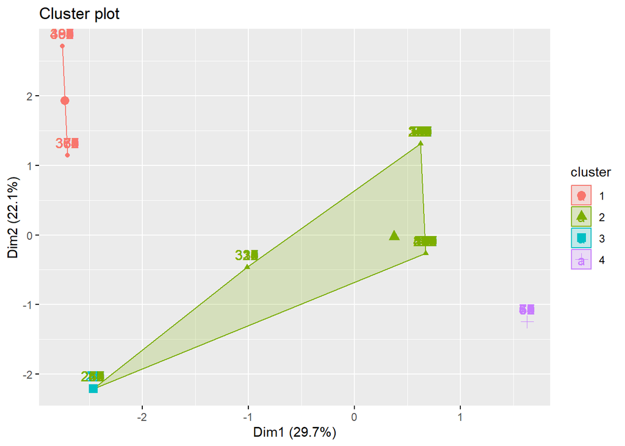

```r
fviz_cluster(kmeans.result, data = subset_dataset)
```

```r
kmeans.result$tot.withinss
```

```
## [1] 1194.82
```

```
##   cluster size ave.sil.width
## 1       1   48          0.73
## 2       2  406          0.66
## 3       3   24          1.00
## 4       4   24          1.00
```

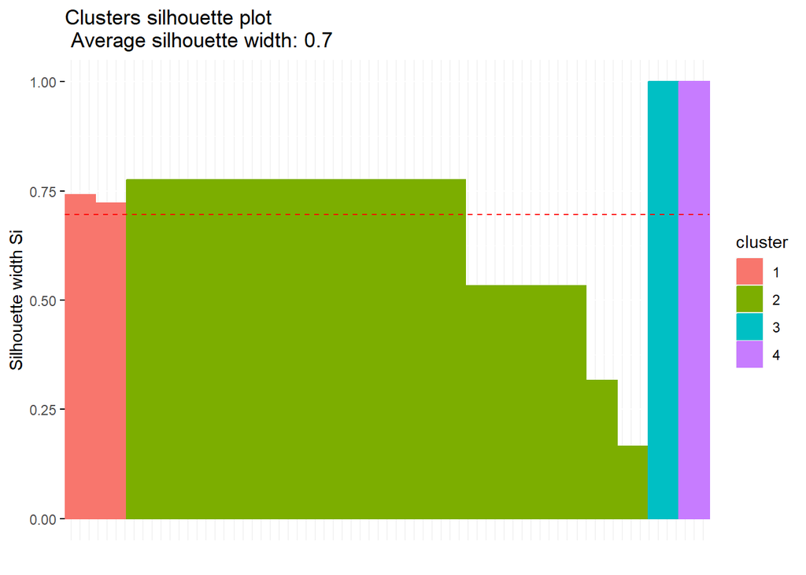

```r
#silhouette
library(cluster)
avg_sil <- silhouette(kmeans.result$cluster,dist(subset_dataset)) #a dissimilarity object inheriting from class dist or coercible to one. If not specified, dmatrix must be.
fviz_silhouette(avg_sil)#k-means clustering with estimating k and initializations
```

```r
#BCubed precision and recall
for (i in 1:length(class_labels)) {
  BCubed_precision_recall_results[i, 1] <- calculate_BCubed_precision(kmeans.result$cluster, yes1$Hotel.stars, class_labels[i])
  BCubed_precision_recall_results[i, 2] <- calculate_BCubed_recall(kmeans.result$cluster, yes1$Hotel.stars, class_labels[i])
}



# View the results
print(BCubed_precision_recall_results)
```

```
##     BCubed_Precision BCubed_Recall
## 3          0.1912351     0.4402390
## 3,5        0.0000000           NaN
## 4          0.2350598     0.6539942
## 4,5        0.0000000           NaN
## 5          0.3824701     0.8087649
```

```r
#print(BCubed_precision_recall_results)
#BCubed_Precision BCubed_Recall
#3         0.19161677     0.4401198
#3,5       0.14371257     0.5708583
#4         0.23552894     0.6537095
#4,5       0.04790419     0.8083832
#5         0.38123752     0.8083832
```

**run k-means clustering to find 2 clusters**

```r
set.seed(8953)



kmeans.result2 <- kmeans(subset_dataset, 2)
kmeans.result2
```

```
## K-means clustering with 2 clusters of sizes 478, 24
##
## Cluster means:
##          Pool        Gym         Spa Free.internet Tennis.court      Casino
## 1 -0.01123937  0.2238508  0.08949348   -0.01123937   0.02780518 -0.01630959
## 2  0.22385081 -4.4583620 -1.78241186    0.22385081  -0.55378654  0.32483267
##
## Clustering vector:
##   1   2   3   4   5   6   7   8   9  10  11  12  13  14  15  16  17  18  19  20
##   1   1   1   1   1   1   1   1   1   1   1   1   1   1   1   1   1   1   1   1
##  21  22  23  24  25  26  27  28  29  30  31  32  33  34  35  36  37  38  39  40
##   1   1   1   1   1   1   1   1   1   1   1   1   1   1   1   1   1   1   1   1
##  41  42  43  44  45  46  47  48  49  50  51  52  53  54  55  56  57  58  59  60
##   1   1   1   1   1   1   1   1   1   1   1   1   1   1   1   1   1   1   1   1
##  61  62  63  64  65  66  67  68  69  70  71  72  73  74  75  77  78  79  80  81
```

[output cut: 54 more lines]

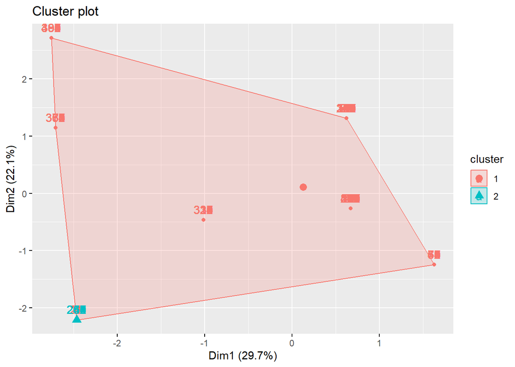

```r
#3- visualize clustering
library(factoextra)
fviz_cluster(kmeans.result2, data = subset_dataset)
```

```r
kmeans.result2$tot.withinss
```

```
## [1] 2412.008
```

```
##   cluster size ave.sil.width
## 1       1  478          0.58
## 2       2   24          1.00
```

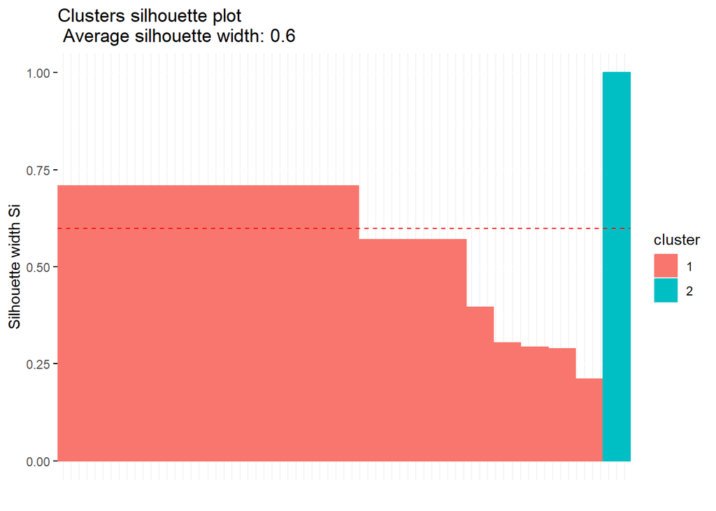

```r
#silhouette
library(cluster)
avg_sil <- silhouette(kmeans.result2$cluster,dist(subset_dataset))
fviz_silhouette(avg_sil)
```

```r
#BCubed precision and recall
for (i in 1:length(class_labels)) {
  BCubed_precision_recall_results[i, 1] <- calculate_BCubed_precision(kmeans.result2$cluster, yes1$Hotel.stars, class_labels[i])
  BCubed_precision_recall_results[i, 2] <- calculate_BCubed_recall(kmeans.result2$cluster, yes1$Hotel.stars, class_labels[i])
}
# View the results
print(BCubed_precision_recall_results)
```

```
##     BCubed_Precision BCubed_Recall
## 3          0.1912351     0.9521912
## 3,5        0.0000000           NaN
## 4          0.2350598     0.9521912
## 4,5        0.0000000           NaN
## 5          0.3824701     0.9521912
```

**run k-means clustering to find 6 clusters**

```r
set.seed(8953)



kmeans.result3 <- kmeans(subset_dataset, 6)
kmeans.result3
```

```
## K-means clustering with 6 clusters of sizes 24, 48, 288, 24, 94, 24
##
## Cluster means:
##         Pool        Gym        Spa Free.internet Tennis.court     Casino
## 1 -4.4583620  0.2238508 -1.7824119     0.2238508   -0.5537865  0.3248327
## 2  0.2238508  0.2238508 -1.7824119     0.2238508    0.6241831 -3.0723756
## 3  0.2238508  0.2238508  0.3647256     0.2238508   -0.5537865  0.3248327
## 4  0.2238508  0.2238508  0.5599200    -4.4583620   -0.5537865  0.3248327
## 5  0.2238508  0.2238508  0.5599200     0.2238508    1.8021528  0.3248327
## 6  0.2238508 -4.4583620 -1.7824119     0.2238508   -0.5537865  0.3248327
##
## Clustering vector:
##   1   2   3   4   5   6   7   8   9  10  11  12  13  14  15  16  17  18  19  20
##   1   1   1   1   1   1   1   1   1   1   1   1   1   1   1   1   1   1   1   1
##  21  22  23  24  25  26  27  28  29  30  31  32  33  34  35  36  37  38  39  40
```

[output cut: 59 more lines]

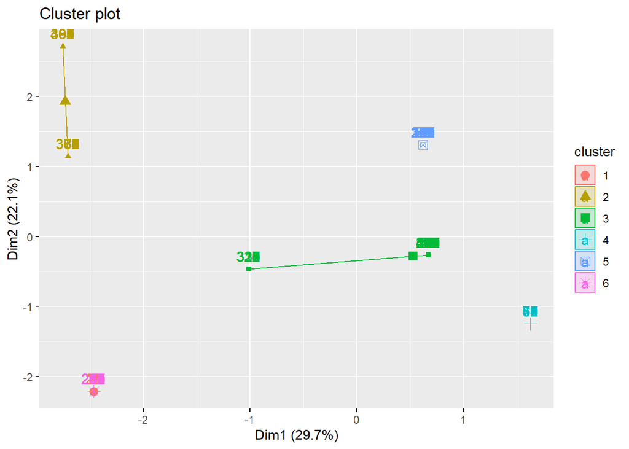

```r
#3- visualize clustering
library(factoextra)
fviz_cluster(kmeans.result3, data = subset_dataset)
```

```r
kmeans.result3$tot.withinss
```

```
## [1] 187.3088
```

```
##   cluster size ave.sil.width
## 1       1   24          1.00
## 2       2   48          0.71
## 3       3  288          0.87
## 4       4   24          1.00
## 5       5   94          1.00
## 6       6   24          1.00
```

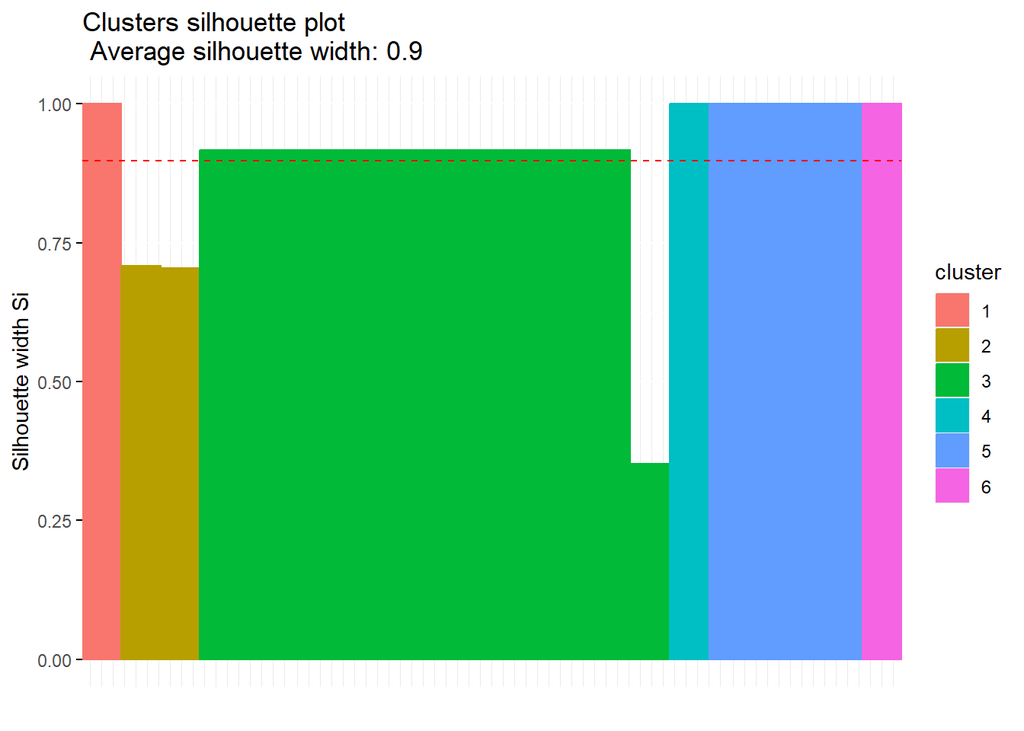

```r
#silhouette
library(cluster)
avg_sil <- silhouette(kmeans.result3$cluster,dist(subset_dataset))
fviz_silhouette(avg_sil)
```

```r
#BCubed precision and recall
for (i in 1:length(class_labels)) {
  BCubed_precision_recall_results[i, 1] <- calculate_BCubed_precision(kmeans.result3$cluster, yes1$Hotel.stars, class_labels[i])
  BCubed_precision_recall_results[i, 2] <- calculate_BCubed_recall(kmeans.result3$cluster, yes1$Hotel.stars, class_labels[i])
}
# View the results
print(BCubed_precision_recall_results)
```

```
##     BCubed_Precision BCubed_Recall
## 3          0.1912351     0.2260956
## 3,5        0.0000000           NaN
## 4          0.2350598     0.3160916
## 4,5        0.0000000           NaN
## 5          0.3824701     0.5253984
```

For Clustering, we used K-means algorithm with 3 different K to find the optimal number of clusters, we took k=4, k=6, k=2 we calculated the average silhouette width for each K, and we concluded the following results: Number (K)= 4, the average silhouette width=0.7 Number (K)= 2, the average silhouette width=0.6 Number (K)= 6, the average silhouette width=0.9 The model that has the optimal number of clusters is 6-Mean since it has the best average silhouette width which means that objects within the same cluster are close to each other and as far as possible to the objects in the other cluster.